# Assignment_2

2023-02-21

Data Exploration

Open the file bank-names.txt and carefully read the attribute information to understand what information is stored in each attribute, what values each attribute can take and so on.

1. (1pt) Download the dataset and store it in a dataframe in R. Note: the attributes are separated by semicolon so make sure you set “sep” option correctly inside read.csv

```r
bank_dataset = read.csv("C:/ML/bank-full.csv", sep=";", na.strings = c("unknown",""))
```

2. (2 pt) Explore the overall structure of the dataset using the str() function. Get a summary statistics of each variable. Explain what is the type of each variable ( categorical( unordered), categorical (ordered), or continuous).

```r
str(bank_dataset)
```

```
## 'data.frame':    45211 obs. of  17 variables:
##  $ age      : int  58 44 33 47 33 35 28 42 58 43 ...
##  $ job      : chr  "management" "technician" "entrepreneur" "blue-collar" ...
##  $ marital  : chr  "married" "single" "married" "married" ...
##  $ education: chr  "tertiary" "secondary" "secondary" NA ...
##  $ default  : chr  "no" "no" "no" "no" ...
##  $ balance  : int  2143 29 2 1506 1 231 447 2 121 593 ...
##  $ housing  : chr  "yes" "yes" "yes" "yes" ...
##  $ loan     : chr  "no" "no" "yes" "no" ...
##  $ contact  : chr  NA NA NA NA ...
##  $ day      : int  5 5 5 5 5 5 5 5 5 5 ...
##  $ month    : chr  "may" "may" "may" "may" ...
##  $ duration : int  261 151 76 92 198 139 217 380 50 55 ...
##  $ campaign : int  1 1 1 1 1 1 1 1 1 1 ...
##  $ pdays    : int  -1 -1 -1 -1 -1 -1 -1 -1 -1 -1 ...
##  $ previous : int  0 0 0 0 0 0 0 0 0 0 ...
##  $ poutcome : chr  NA NA NA NA ...
##  $ y        : chr  "no" "no" "no" "no" ...
```

```r
summary(bank_dataset)
```

```
##       age            job              marital           education
##  Min.   :18.00   Length:45211       Length:45211       Length:45211
##  1st Qu.:33.00   Class :character   Class :character   Class :character
##  Median :39.00   Mode  :character   Mode  :character   Mode  :character
##  Mean   :40.94
##  3rd Qu.:48.00
##  Max.   :95.00
##    default             balance         housing              loan
##  Length:45211       Min.   : -8019   Length:45211       Length:45211
##  Class :character   1st Qu.:    72   Class :character   Class :character
##  Mode  :character   Median :   448   Mode  :character   Mode  :character
##                     Mean   :  1362
##                     3rd Qu.:  1428
##                     Max.   :102127
##    contact               day           month              duration
##  Length:45211       Min.   : 1.00   Length:45211       Min.   :   0.0
##  Class :character   1st Qu.: 8.00   Class :character   1st Qu.: 103.0
##  Mode  :character   Median :16.00   Mode  :character   Median : 180.0
##                     Mean   :15.81                      Mean   : 258.2
##                     3rd Qu.:21.00                      3rd Qu.: 319.0
##                     Max.   :31.00                      Max.   :4918.0
##     campaign          pdays          previous          poutcome
##  Min.   : 1.000   Min.   : -1.0   Min.   :  0.0000   Length:45211
##  1st Qu.: 1.000   1st Qu.: -1.0   1st Qu.:  0.0000   Class :character
##  Median : 2.000   Median : -1.0   Median :  0.0000   Mode  :character
##  Mean   : 2.764   Mean   : 40.2   Mean   :  0.5803
##  3rd Qu.: 3.000   3rd Qu.: -1.0   3rd Qu.:  0.0000
##  Max.   :63.000   Max.   :871.0   Max.   :275.0000
##       y
##  Length:45211
##  Class :character
##  Mode  :character
##
##
##
```

age: continuous job: categorical (unordered) marital: categorical (unordered) education: categorical (unordered) default: categorical (unordered) balance: continuous housing: categorical (unordered) loan: categorical (unordered) contact: categorical (unordered) day: continuous month: categorical (ordered) duration: continuous campaign: continuous pdays: continuous previous: continuous poutcome: categorical (unordered) y: categorical (unordered)

3. (1pt) Get the frequency table of the target variable “y” to see how many observations you have in each category of y. Is y balanced? that is, do you have roughly same observations in y=yes and y=no?

```r
table(bank_dataset$y)
```

```
##
##    no   yes
## 39922  5289
```

```r
y_freq = prop.table(table(bank_dataset$y)) * 100
y_freq
```

```
##
##       no      yes
## 88.30152 11.69848
```

This output shows that 88.3% of the observations fall into the y category of “no,” whereas 11.7% go into the y category of “yes.” Because there are noticeably more observations in the “no” category than in the “yes” category, we can infer that y is not balanced.

4. (3 pts) Explore the data in order to investigate the association between the target variable y and other variables in the dataset. Which of the other variables are associated with y? Use appropriate plots and statistic tests to answer this question.

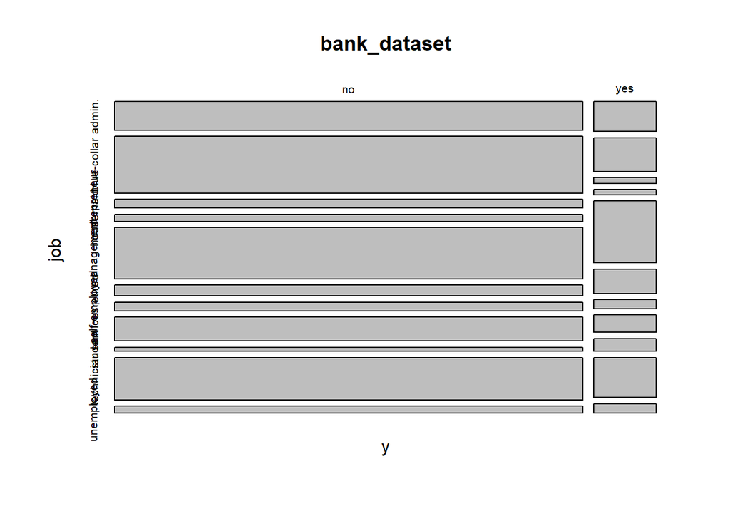

```r
mosaicplot(y~job, data = bank_dataset)
```

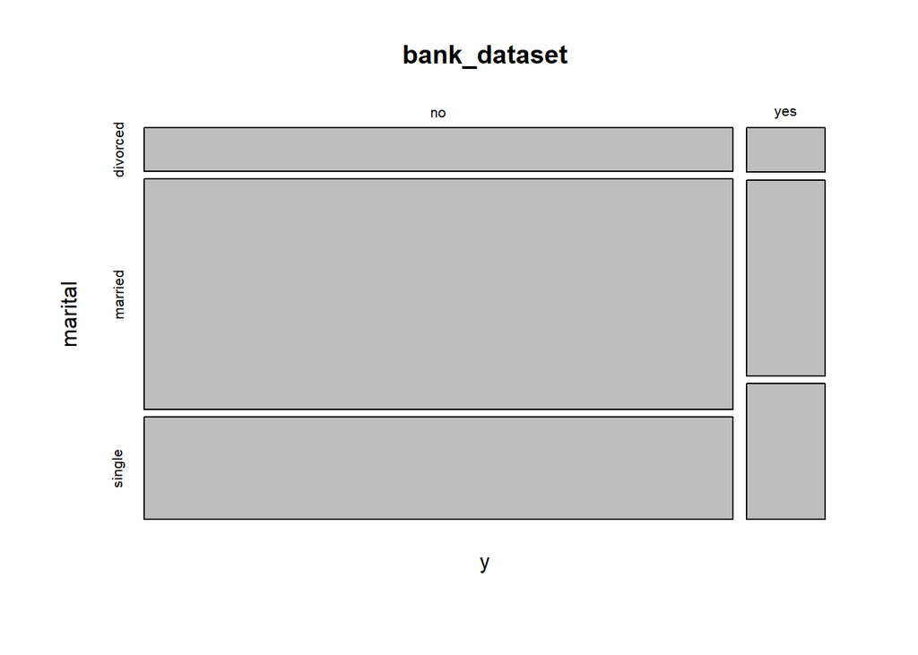

```r
mosaicplot(y~marital, data = bank_dataset)
```

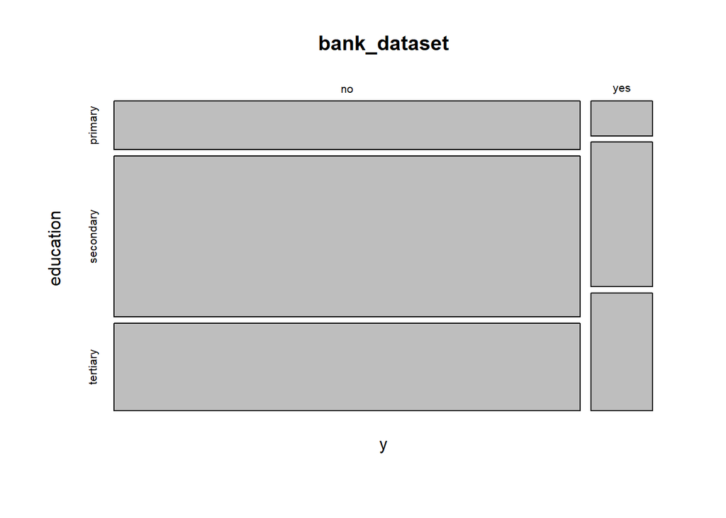

```r
mosaicplot(y~education, data = bank_dataset)
```

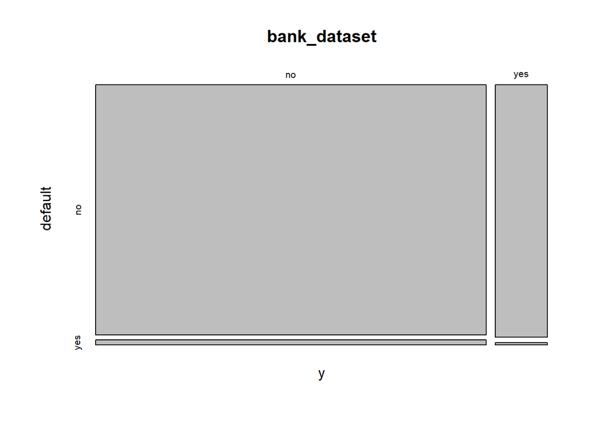

```r
mosaicplot(y~default, data = bank_dataset)
```

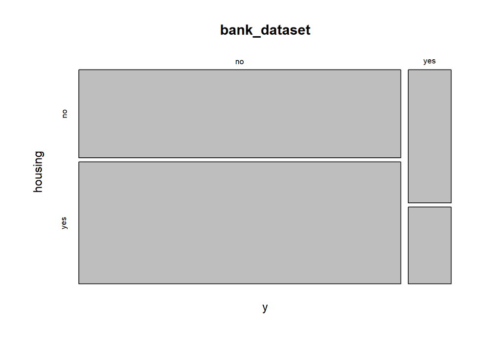

```r
mosaicplot(y~housing, data = bank_dataset)
```

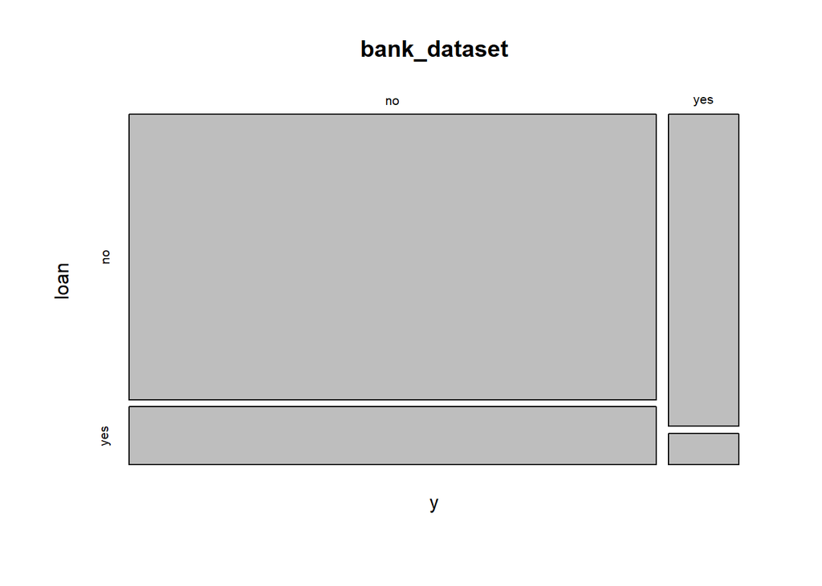

```r
mosaicplot(y~loan, data = bank_dataset)
```

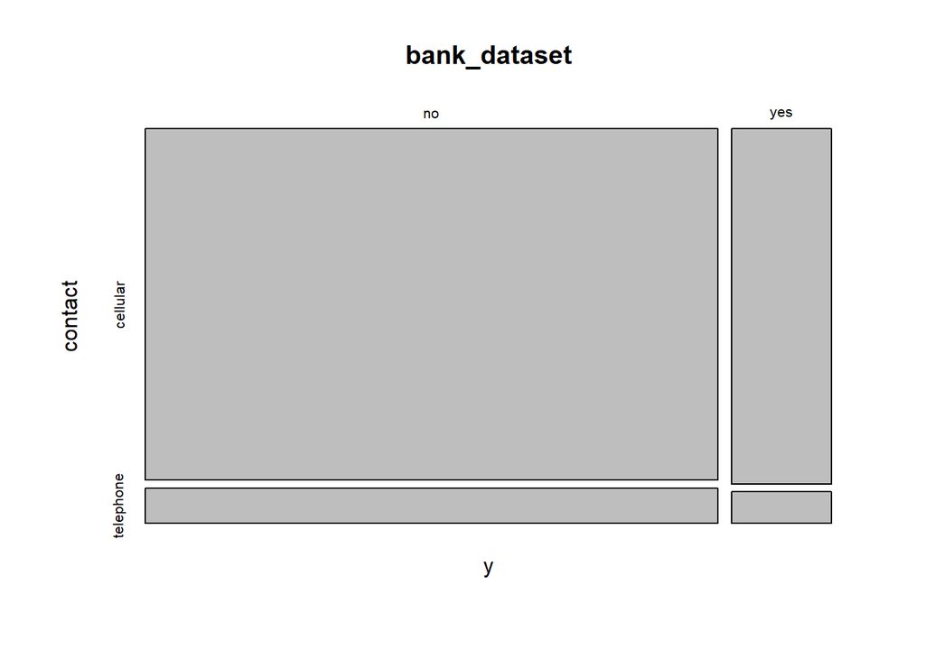

```r
mosaicplot(y~contact, data = bank_dataset)
```

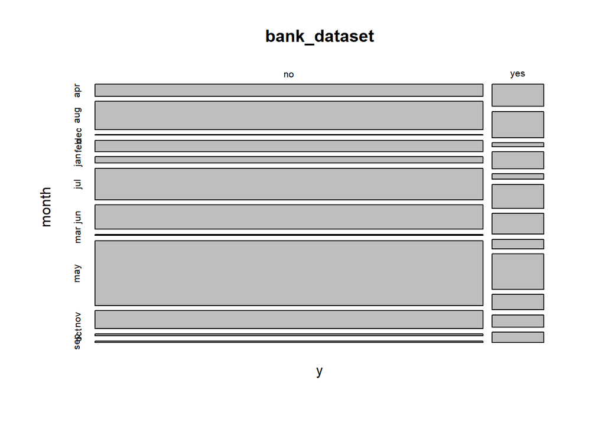

```r
mosaicplot(y~month, data = bank_dataset)
```

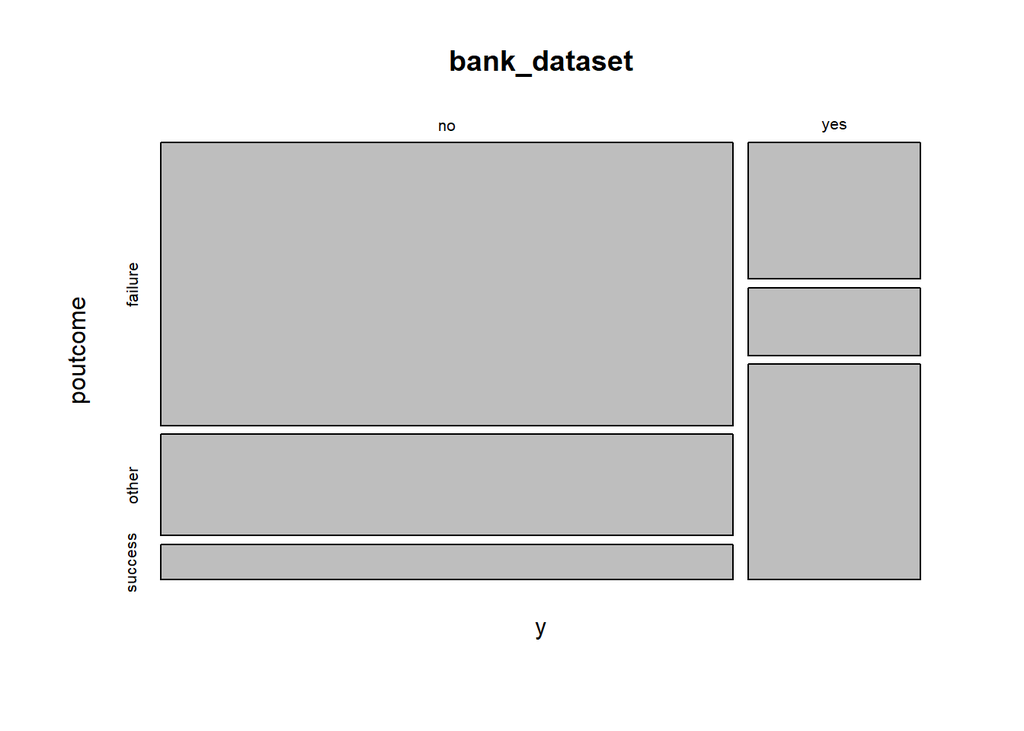

```r
mosaicplot(y~poutcome, data = bank_dataset)
```

```r
test1 = chisq.test(table(bank_dataset$job , bank_dataset$y ))
test2 = chisq.test(table(bank_dataset$marital , bank_dataset$y ))
test3 = chisq.test(table(bank_dataset$education , bank_dataset$y ))
test4 = chisq.test(table(bank_dataset$default , bank_dataset$y ))
test5 = chisq.test(table(bank_dataset$housing , bank_dataset$y ))
test6 = chisq.test(table(bank_dataset$loan , bank_dataset$y))
test7 = chisq.test(table(bank_dataset$contact , bank_dataset$y))
test8 = chisq.test(table(bank_dataset$month , bank_dataset$y))
test9 = chisq.test(table(bank_dataset$poutcome , bank_dataset$y ))

test1
```

```
##
##  Pearson's Chi-squared test
##
## data:  table(bank_dataset$job, bank_dataset$y)
## X-squared = 836.14, df = 10, p-value < 2.2e-16
```

```r
test2
```

```
##
##  Pearson's Chi-squared test
##
## data:  table(bank_dataset$marital, bank_dataset$y)
## X-squared = 196.5, df = 2, p-value < 2.2e-16
```

```r
test3
```

```
##
##  Pearson's Chi-squared test
##
## data:  table(bank_dataset$education, bank_dataset$y)
## X-squared = 233.75, df = 2, p-value < 2.2e-16
```

```r
test4
```

```
##
##  Pearson's Chi-squared test with Yates' continuity correction
##
## data:  table(bank_dataset$default, bank_dataset$y)
## X-squared = 22.202, df = 1, p-value = 2.454e-06
```

```r
test5
```

```
##
##  Pearson's Chi-squared test with Yates' continuity correction
##
## data:  table(bank_dataset$housing, bank_dataset$y)
## X-squared = 874.82, df = 1, p-value < 2.2e-16
```

```r
test6
```

```
##
##  Pearson's Chi-squared test with Yates' continuity correction
##
## data:  table(bank_dataset$loan, bank_dataset$y)
## X-squared = 209.62, df = 1, p-value < 2.2e-16
```

```r
test7
```

```
##
##  Pearson's Chi-squared test with Yates' continuity correction
##
## data:  table(bank_dataset$contact, bank_dataset$y)
## X-squared = 4.5932, df = 1, p-value = 0.0321
```

```r
test8
```

```
##
##  Pearson's Chi-squared test
##
## data:  table(bank_dataset$month, bank_dataset$y)
## X-squared = 3061.8, df = 11, p-value < 2.2e-16
```

```r
test9
```

```
##
##  Pearson's Chi-squared test
##
## data:  table(bank_dataset$poutcome, bank_dataset$y)
## X-squared = 1822.2, df = 2, p-value < 2.2e-16
```

Based on the Pearson’s chi-squared tests that you have provided, all variables seem to be significantly associated with the outcome variable, y. This includes the job, marital status, education, default, housing, loan, contact, month, and poutcome variables. The null hypothesis for these tests is that there is no association between the two variables, while the alternative hypothesis is that there is an association. Since all p-values are less than 0.05, we reject the null hypothesis and conclude that there is an association between each variable and the outcome variable.

```r
sapply(bank_dataset[, c("age", "y")], function(x) any(!is.numeric(x)))
```

```
##   age     y
## FALSE  TRUE
```

```r
bank_dataset$y_binary = ifelse(bank_dataset$y == "yes", 1, 0)
```

```r
str(bank_dataset)
```

```
## 'data.frame':    45211 obs. of  18 variables:
##  $ age      : int  58 44 33 47 33 35 28 42 58 43 ...
##  $ job      : chr  "management" "technician" "entrepreneur" "blue-collar" ...
##  $ marital  : chr  "married" "single" "married" "married" ...
##  $ education: chr  "tertiary" "secondary" "secondary" NA ...
##  $ default  : chr  "no" "no" "no" "no" ...
##  $ balance  : int  2143 29 2 1506 1 231 447 2 121 593 ...
##  $ housing  : chr  "yes" "yes" "yes" "yes" ...
##  $ loan     : chr  "no" "no" "yes" "no" ...
##  $ contact  : chr  NA NA NA NA ...
##  $ day      : int  5 5 5 5 5 5 5 5 5 5 ...
##  $ month    : chr  "may" "may" "may" "may" ...
##  $ duration : int  261 151 76 92 198 139 217 380 50 55 ...
##  $ campaign : int  1 1 1 1 1 1 1 1 1 1 ...
##  $ pdays    : int  -1 -1 -1 -1 -1 -1 -1 -1 -1 -1 ...
##  $ previous : int  0 0 0 0 0 0 0 0 0 0 ...
##  $ poutcome : chr  NA NA NA NA ...
##  $ y        : chr  "no" "no" "no" "no" ...
##  $ y_binary : num  0 0 0 0 0 0 0 0 0 0 ...
```

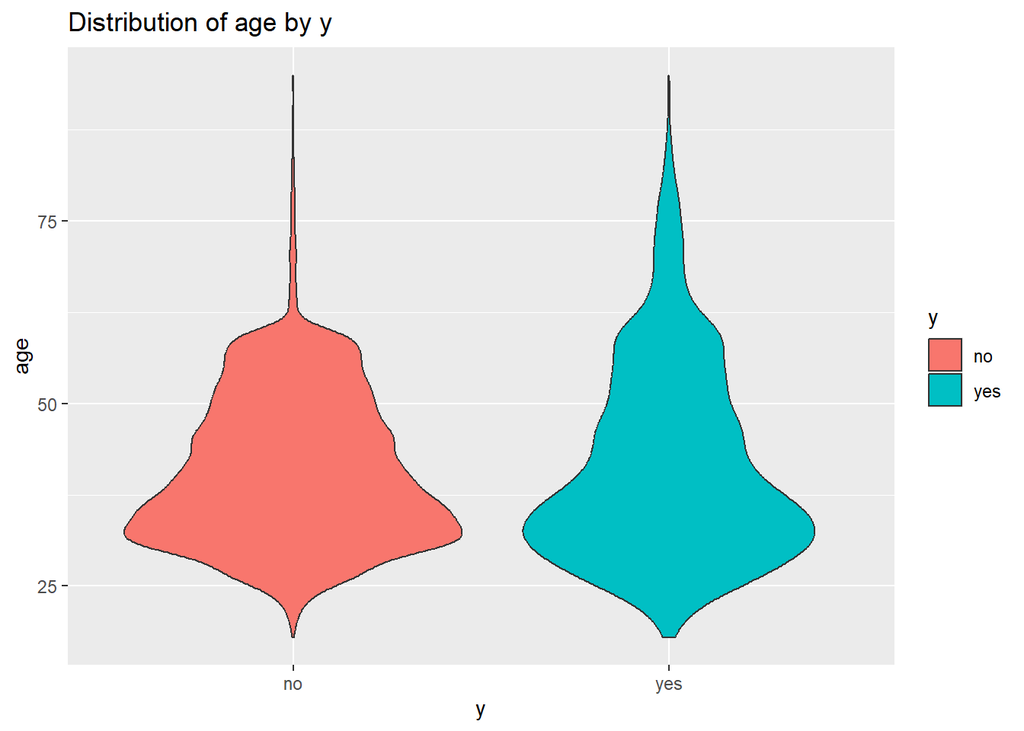

```r
#install.packages("ggplot2")

library(ggplot2)

ggplot(bank_dataset, aes(x = y, y = age, fill = y)) +
  geom_violin() +
  labs(title = "Distribution of age by y") +
  xlab("y") +
  ylab("age")
```

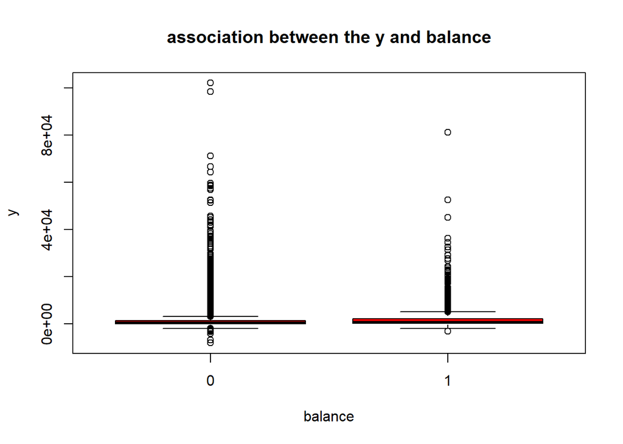

```r
boxplot(bank_dataset$balance ~ bank_dataset$y_binary,
        col='red',
        main='association between the y and balance',
        xlab='balance',
        ylab='y')
```

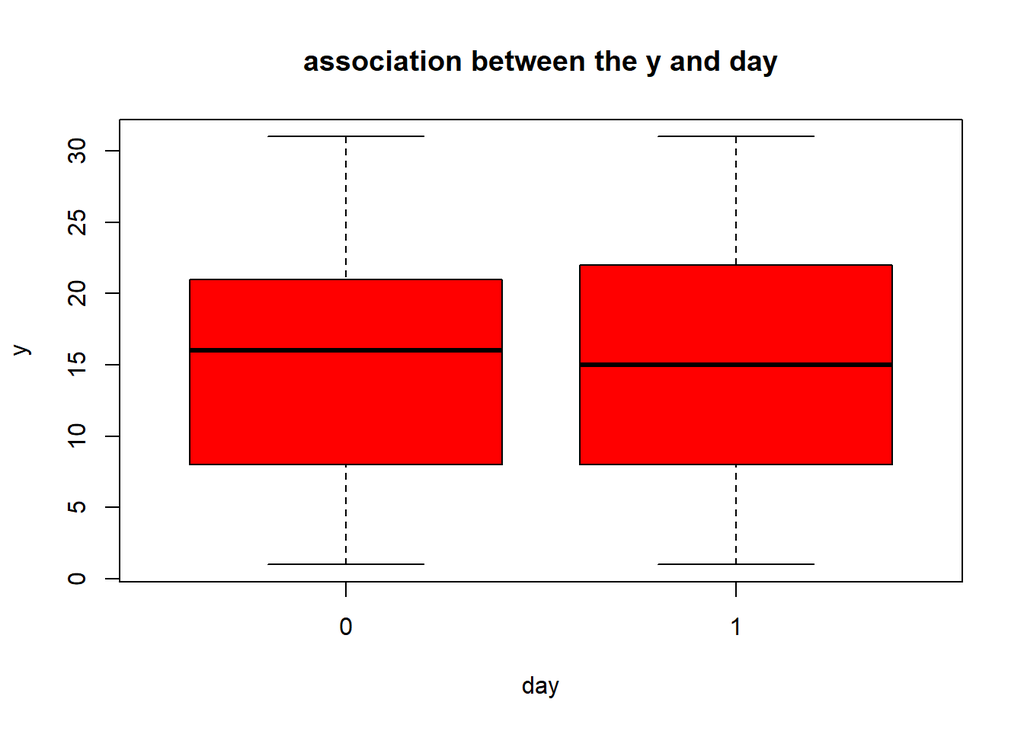

```r
boxplot(bank_dataset$day ~ bank_dataset$y_binary,
        col='red',
        main='association between the y and day',
        xlab='day',
        ylab='y')
```

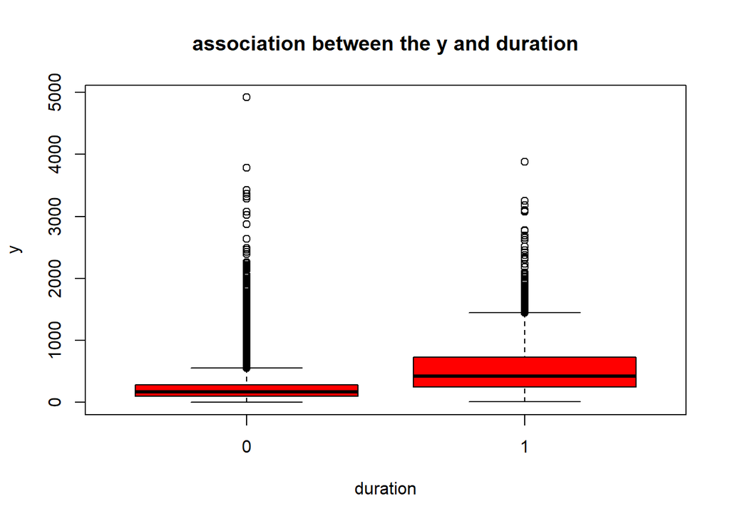

```r
boxplot(bank_dataset$duration ~ bank_dataset$y_binary,
        col='red',
        main='association between the y and duration',
        xlab='duration',
        ylab='y')
```

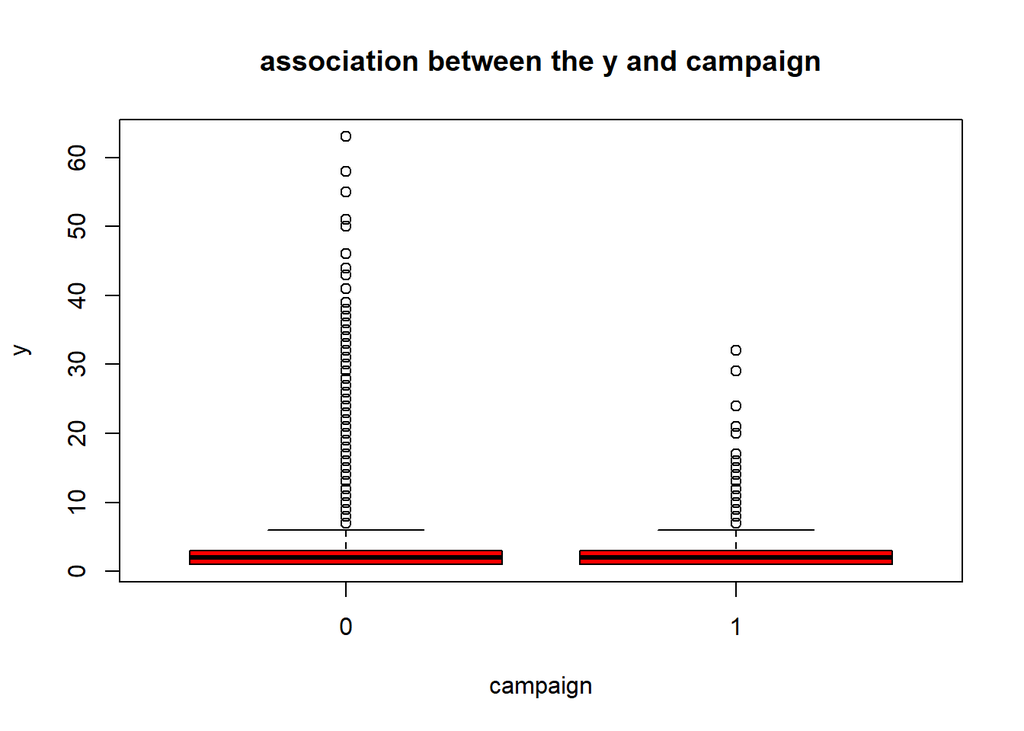

```r
boxplot(bank_dataset$campaign ~ bank_dataset$y_binary,
        col='red',
        main='association between the y and campaign',
        xlab='campaign',
        ylab='y')
```

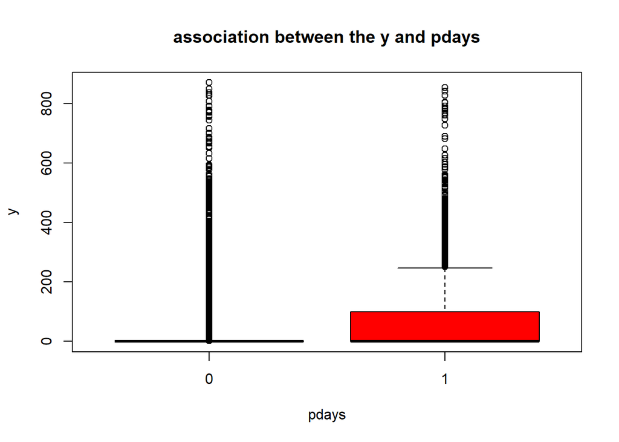

```r
boxplot(bank_dataset$pdays ~ bank_dataset$y_binary,
        col='red',
        main='association between the y and pdays',
        xlab='pdays',
        ylab='y')
```

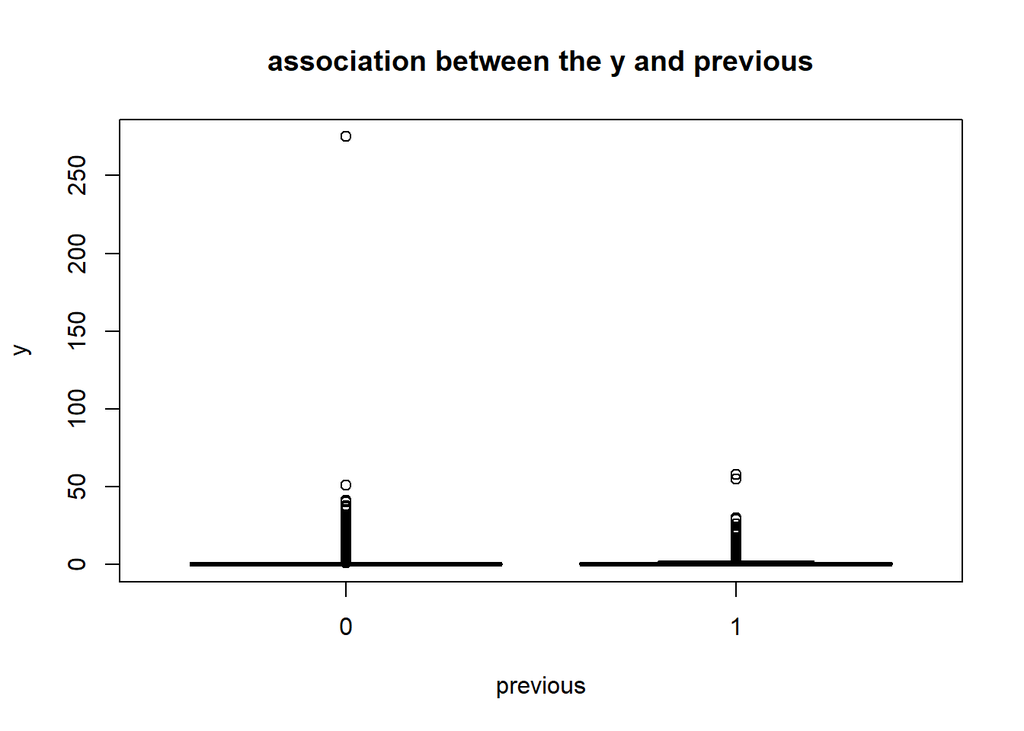

```r
boxplot(bank_dataset$previous ~ bank_dataset$y_binary,
        col='red',
        main='association between the y and previous',
        xlab='previous',
        ylab='y')
```

```r
t.test(bank_dataset$age~bank_dataset$y_binary)
```

```
##
##  Welch Two Sample t-test
##
## data:  bank_dataset$age by bank_dataset$y_binary
## t = -4.3183, df = 6109.2, p-value = 1.597e-05
## alternative hypothesis: true difference in means between group 0 and group 1 is not equal to 0
## 95 percent confidence interval:
##  -1.2083645 -0.4538034
## sample estimates:
## mean in group 0 mean in group 1
##        40.83899        41.67007
```

```r
t.test(bank_dataset$balance~bank_dataset$y_binary)
```

```
##
##  Welch Two Sample t-test
##
## data:  bank_dataset$balance by bank_dataset$y_binary
## t = -9.9335, df = 6339.8, p-value < 2.2e-16
## alternative hypothesis: true difference in means between group 0 and group 1 is not equal to 0
## 95 percent confidence interval:
##  -599.3347 -401.7712
## sample estimates:
## mean in group 0 mean in group 1
##        1303.715        1804.268
```

```r
t.test(bank_dataset$day~bank_dataset$y_binary)
```

```
##
##  Welch Two Sample t-test
##
## data:  bank_dataset$day by bank_dataset$y_binary
## t = 5.917, df = 6691.7, p-value = 3.441e-09
## alternative hypothesis: true difference in means between group 0 and group 1 is not equal to 0
## 95 percent confidence interval:
##  0.4908478 0.9772262
## sample estimates:
## mean in group 0 mean in group 1
##        15.89229        15.15825
```

```r
t.test(bank_dataset$duration~bank_dataset$y_binary)
```

```
##
##  Welch Two Sample t-test
##
## data:  bank_dataset$duration by bank_dataset$y_binary
## t = -57.514, df = 5685.3, p-value < 2.2e-16
## alternative hypothesis: true difference in means between group 0 and group 1 is not equal to 0
## 95 percent confidence interval:
##  -326.8865 -305.3370
## sample estimates:
## mean in group 0 mean in group 1
##        221.1828        537.2946
```

```r
t.test(bank_dataset$campaign~bank_dataset$y_binary)
```

```
##
##  Welch Two Sample t-test
##
## data:  bank_dataset$campaign by bank_dataset$y_binary
## t = 22.801, df = 9751.6, p-value < 2.2e-16
## alternative hypothesis: true difference in means between group 0 and group 1 is not equal to 0
## 95 percent confidence interval:
##  0.6446672 0.7659387
## sample estimates:
## mean in group 0 mean in group 1
##        2.846350        2.141047
```

```r
t.test(bank_dataset$pdays~bank_dataset$y_binary)
```

```
##
##  Welch Two Sample t-test
##
## data:  bank_dataset$pdays by bank_dataset$y_binary
## t = -18.943, df = 6251.5, p-value < 2.2e-16
## alternative hypothesis: true difference in means between group 0 and group 1 is not equal to 0
## 95 percent confidence interval:
##  -35.62222 -28.94097
## sample estimates:
## mean in group 0 mean in group 1
##        36.42137        68.70297
```

```r
t.test(bank_dataset$previous~bank_dataset$y_binary)
```

```
##
##  Welch Two Sample t-test
##
## data:  bank_dataset$previous by bank_dataset$y_binary
## t = -18.118, df = 6430.1, p-value < 2.2e-16
## alternative hypothesis: true difference in means between group 0 and group 1 is not equal to 0
## 95 percent confidence interval:
##  -0.7404974 -0.5959014
## sample estimates:
## mean in group 0 mean in group 1
##       0.5021542       1.1703536
```

```r
bank_dataset = bank_dataset[, !(names(bank_dataset) %in% c("day", "duration","y_binary"))]
```

```r
str(bank_dataset)
```

```
## 'data.frame':    45211 obs. of  15 variables:
##  $ age      : int  58 44 33 47 33 35 28 42 58 43 ...
##  $ job      : chr  "management" "technician" "entrepreneur" "blue-collar" ...
##  $ marital  : chr  "married" "single" "married" "married" ...
##  $ education: chr  "tertiary" "secondary" "secondary" NA ...
##  $ default  : chr  "no" "no" "no" "no" ...
##  $ balance  : int  2143 29 2 1506 1 231 447 2 121 593 ...
##  $ housing  : chr  "yes" "yes" "yes" "yes" ...
##  $ loan     : chr  "no" "no" "yes" "no" ...
##  $ contact  : chr  NA NA NA NA ...
##  $ month    : chr  "may" "may" "may" "may" ...
##  $ campaign : int  1 1 1 1 1 1 1 1 1 1 ...
##  $ pdays    : int  -1 -1 -1 -1 -1 -1 -1 -1 -1 -1 ...
##  $ previous : int  0 0 0 0 0 0 0 0 0 0 ...
##  $ poutcome : chr  NA NA NA NA ...
##  $ y        : chr  "no" "no" "no" "no" ...
```

Data Preparation:

5. (1pt) Use the command colSums(is.na() to get the number of missing valuesin each column of your dataframe. Which columns have missing values? Note: some variables use “unknown” for missing values. Convert all “unknown” values to NA. You can do so by setting “na.strings” parameter to “unknown” when you read the file using read.csv.

```r
colSums(is.na(bank_dataset))
```

```
##       age       job   marital education   default   balance   housing      loan
##         0       288         0      1857         0         0         0         0
##   contact     month  campaign     pdays  previous  poutcome         y
##     13020         0         0         0         0     36959         0
```

Based on the above states, we can assume that there missing values in the Job,Education,Contact,poutcome.

6. (3 pt) There are several ways we can deal with missing values. The easiest approach isto remove all the rows with missing values. However, if a large number of rows have missing values removing them will result in loss of information and may affect the classifier performance. If a large number of rows have missing values, then it is typically better to substitute missing values. This is called data imputation. Several methods for missing data imputation exist. The most naïve method (which we will use here) is to replace the missing values with mean of the column (for a numerical column) or mode/majority value of the column (for a categorical column). We will use a more advanced data imputation method in a later module. For now, replace the missing values in a numerical column with the mean of the column and the missing values in a categorical column with the mode/majority of the column. After imputation, use colSums(is.na() to make sure that your dataframe no longer has missing values.

```r
bank_dataset$job[is.na(bank_dataset$job)]=names(sort(-table(bank_dataset$job)))[1]


bank_dataset$education[is.na(bank_dataset$education)]=names(sort(-table(bank_dataset$education)))[1]


bank_dataset$contact[is.na(bank_dataset$contact)]=names(sort(-table(bank_dataset$contact)))[1]

# Replace missing values in poutcome column with "unknown"
bank_dataset$poutcome[is.na(bank_dataset$poutcome)] = "unknown"
```

```r
colSums(is.na(bank_dataset))
```

```
##       age       job   marital education   default   balance   housing      loan
##         0         0         0         0         0         0         0         0
##   contact     month  campaign     pdays  previous  poutcome         y
##         0         0         0         0         0         0         0
```

7. Set the seed of the random number generator to a fixed integer, say 1, so that I can reproduce your work:

```r
set.seed(1)
```

8. (1pt) Randomize the order of the rowsin the dataset

```r
bank_dataset = bank_dataset[sample(nrow(bank_dataset)),]
```

9. (2 pt) This dataset has several categorical variables. With the exception of few models ( such as Naiive Bayes and tree-based models) most machine learning models require numeric features and cannot work directly with categorical data. One way to deal with categorical variables is to assign numeric indices to each level. However, this imposes an artificial ordering on an unordered categorical variable. For example, suppose that we have a categorical variable primary color with three levels: “red”,”blue”,”green”. If we convert “red” to 0 , “blue” to 1 and “green” to 2 then we are telling our model that red < blue< green which is not correct. A better way to encode an unordered categorical variable is to do one-hot-encoding. In one hot-encoding we create a dummy binary variable for each level of a categorical variable. For example we can represent the primary color variable by three binary dummy variables, one for each color (red, blue, and green) . If the color is red, then the variable red takes value 1 while blue and green both take the value zero.Do one-hot-encoding of all your unordered categorical variables (except the target variable y). You can use the function one_hot from mltools package to one-hot encode all categorical variables in a dataset.

Please refer to https://rdrr.io/cran/mltools/man/one_hot.html . Use option DropUnusedLevels=True to avoid creating a binary variable for unused levels of a factor variable. Please note that the one_hot function takes a data table not a dataframe. You can convert a dataframe to datatable by using as.data.table method https://www.rdocumentation.org/packages/data.table/versions/1.12.8/topics/as.data.table. Make sure to use library(data.table) before using as.data.table method. You can covert a datatable back to a dataframe by using as.data.frame method https://www.rdocumentation.org/packages/base/versions/3.6.2/topics/as.data.frame

```r
bank_dataset[sapply(bank_dataset, is.character)] = lapply(bank_dataset[sapply(bank_dataset, is.character)], as.factor)

str(bank_dataset)
```

```
## 'data.frame':    45211 obs. of  15 variables:
##  $ age      : int  31 38 27 57 38 55 53 30 40 45 ...
##  $ job      : Factor w/ 11 levels "admin.","blue-collar",..: 1 5 1 6 7 2 6 8 10 2 ...
##  $ marital  : Factor w/ 3 levels "divorced","married",..: 2 2 3 2 2 3 2 3 2 2 ...
##  $ education: Factor w/ 3 levels "primary","secondary",..: 3 2 2 2 3 1 1 2 2 2 ...
##  $ default  : Factor w/ 2 levels "no","yes": 1 1 1 1 1 1 1 1 1 1 ...
##  $ balance  : int  1144 76 276 2020 3139 1187 61 603 7313 1678 ...
##  $ housing  : Factor w/ 2 levels "no","yes": 2 1 2 1 2 2 1 2 2 2 ...
##  $ loan     : Factor w/ 2 levels "no","yes": 2 1 1 1 1 1 2 2 1 1 ...
##  $ contact  : Factor w/ 2 levels "cellular","telephone": 1 1 1 1 1 1 1 1 1 1 ...
##  $ month    : Factor w/ 12 levels "apr","aug","dec",..: 10 8 9 7 10 1 6 7 10 10 ...
##  $ campaign : int  1 1 2 4 2 1 1 2 2 1 ...
##  $ pdays    : int  -1 -1 -1 -1 -1 319 -1 -1 182 154 ...
##  $ previous : int  0 0 0 0 0 2 0 0 1 1 ...
##  $ poutcome : Factor w/ 4 levels "failure","other",..: 4 4 4 4 4 1 4 4 1 1 ...
##  $ y        : Factor w/ 2 levels "no","yes": 1 2 1 1 1 1 1 1 1 1 ...
```

```r
library(data.table)
library(mltools)

# # Convert dataframe to datatable
# bank_dt <- as.data.table(bank_dataset)
#
# # One-hot encode unordered categorical variables
# bank_dt_encoded <- one_hot(bank_dt, dropUnusedLevels = TRUE)
#
# # Convert back to dataframe
# bank_dataset_encoded <- as.data.frame(bank_dt_encoded)

bank_dataset_encoded_x = bank_dataset[, -15]
bank_dataset_encoded_y = bank_dataset['y']


bank_dataset_encoded_x = one_hot(as.data.table(bank_dataset_encoded_x),dropUnusedLevels = TRUE)
bank_dataset_encoded_x= as.data.frame(bank_dataset_encoded_x)
```

```r
library(data.table)
library(mltools)
```

Training and Evaluation of ML models

10. Split the data into training and test sets. Use the first 36168 rows for training and the rest for testing.

```r
library(caret)
set.seed(123) # set random seed for reproducibility

# create indices for train and test sets
train_idx <- 1:36168
test_idx <- (36168 + 1):nrow(bank_dataset_encoded_x)

dim(bank_dataset_encoded_y)
```

```
## [1] 45211     1
```

```r
# split the data into train and test sets
train_data <- bank_dataset_encoded_x[train_idx, ]
test_data <- bank_dataset_encoded_x[test_idx, ]

train_data_y <- bank_dataset_encoded_y[train_idx, ]
test_data_y <- bank_dataset_encoded_y[test_idx, ]

# Select only numeric columns in train_data
num_cols <- sapply(train_data, is.numeric)
bank_train_num <- train_data[, num_cols]
```

11.(2 pt) Scale all numeric features using z-score normalization. Note: Don’t normalize your one-hotencoded variables.

```r
# Scale the numeric features in train_data using z-score normalization
bank_train_num_scaled <- as.data.frame(scale(bank_train_num))

# Combine the scaled numeric features with the one-hot-encoded variables in train_data
bank_train_scaled <- cbind(bank_train_num_scaled, train_data[!num_cols])

# Select only numeric columns in test_data
num_cols_test <- sapply(test_data, is.numeric)
bank_test_num <- test_data[, num_cols_test]

# Scale the numeric features in test_data using z-score normalization
bank_test_num_scaled <- as.data.frame(scale(bank_test_num))

# Combine the scaled numeric features with the one-hot-encoded variables in test_data
bank_test_scaled <- cbind(bank_test_num_scaled, test_data[!num_cols_test])
```

12.(3 pts) Use 5-fold cross validation with KNN on the training set to predict the “y” variable and report the cross-validation accuracy. ( Please use crossValidationError function in slides 51-53 of module 4 lecture notes and modify it to compute accuracy instead of error. The accuracy is simply 1- error).

```r
#install.packages("caret")
library(class)
library(caret)
```

```r
# modify knn_fold function to return accuracy instead of error
knn_fold_acc <- function(features, target, fold, k){
  train <- features[-fold, ]
  validation <- features[fold, ]
  train_labels <- target[-fold]
  validation_labels <- target[fold]
  validation_preds <- knn(train, validation, train_labels, k = k)
  t <- table(validation_labels, validation_preds)
  accuracy <- (t[1, 1] + t[2, 2]) / sum(t)
  return(accuracy)
}

# define cross-validation function to compute average accuracy over all folds
crossValidationAccuracy <- function(features, target, k){
  folds <- createFolds(target, k = 5)
  accuracies <- sapply(folds, knn_fold_acc, features = features, target = target, k = k)
  return(mean(accuracies))
}

# apply cross-validation to the training set
set.seed(123) # set seed for reproducibility
set.seed(123) # set seed for reproducibility
accuracy <- crossValidationAccuracy(bank_train_scaled, train_data_y , k = 5)
accuracy
```

```
## [1] 0.8828798
```

13.(2 pts) Tune K (the number of nearest neighbors) by trying out different values (starting from k=1 to k=sqrt(n) where n is the number of observations in the training set (for example k=1,5,10,20 50,100, sqrt(n) ). Draw a plot of cross validation accuracy for different values of K. Which value of K seems to perform the best on this data set? (Note: the higher the cross validation accuracy ( or the lower the cross validation error) the better is the model. You can find an example in slides 54-55 of module 4 lecture notes) Note: This might take several minutes to run on your machine, be patient.

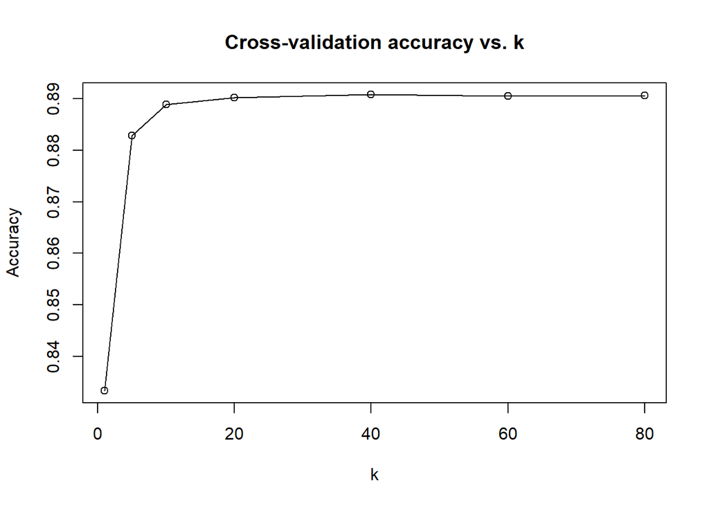

```r
# # create a sequence of k values to try
# ks <- c(1, 5, 10, 20,40)
#
# # apply cross-validation with each k value and record accuracy
# accuracy_list <- list()
# for (k in k_seq) {
#   set.seed(123)
#   accuracy <- crossValidationAccuracy(bank_train_scaled, bank_dataset_encoded_y, k)
#
# # plot the accuracy vs. k
# plot(x = k_seq, y = unlist(accuracy_list), xlab = "K", ylab = "Accuracy")

# define function to compute cross-validation accuracy for a given value of k
knn_cv_acc <- function(k, train_features, train_target){
  set.seed(123) # set seed for reproducibility
  return(crossValidationAccuracy(train_features, train_target, k))
}

# compute range of k values to try
n <- nrow(bank_train_scaled)

k_range <- c(1, 5, 10, 20, 40, 60, 80)

# compute cross-validation accuracy for each value of k
cv_accuracies <- sapply(k_range, knn_cv_acc, train_features = bank_train_scaled, train_target = train_data_y)

# plot cross-validation accuracy vs. k
plot(cv_accuracies ~ k_range, main = "Cross-validation accuracy vs. k", xlab = "k", ylab = "Accuracy")
lines(cv_accuracies ~ k_range)
```

14.(3 pt) Use “knn” function to train a knn model on the training set using the best value of K you found above and get the predicted values for the target variable y in the test set.

```r
# Train KNN model using the best value of K
best_k <- 40
knn_model <- knn(bank_train_scaled, bank_test_scaled, train_data_y, k = best_k)

# Get predicted values for the target variable y in the test set
test_data_y_pred <- as.factor(knn_model)
```

```r
predicted_y <- knn(bank_train_scaled, bank_test_scaled, train_data_y, k = best_k)
```

15.(2pt) Compare the predicted target (y) with the true target (y) in the test set using a cross table.

```r
table(test_data_y, test_data_y_pred)
```

```
##            test_data_y_pred
## test_data_y   no  yes
##         no  7887  114
##         yes  832  210
```